# MATH 9102 - Probability and Statistical Inference Assignment - 3

Antonio Silva (D23129331@mytudublin.ie)

# Question 1 - PCA

1. What do eigenvectors of the covariance matrix gives us? [1 mark]
2. When can we decide to compress the data in PCA process? Explain the effects if any. [1 mark]
3. Read the glass identification data provided. Apply PCA algorithm to reduce the dimensions. Analyze your findings. [2.5 marks]

Reading the glass dataset: Save the read dataset in a variable called “glass”. Do not change the variable name. For example `glass <- read.csv("glassidentificarion.csv")`

## Answer

### a

The eigenvectors of a covariance matrix indicate the directions in which the data varies the most. We examine how the variables correlate or vary with each other in an iterative process, moving in orthogonal directions at each step.

The first eigenvector represents the direction with the greatest variance. The second iteration identifies the direction with the greatest variance that is also perpendicular to the first vector. The third finds the greatest variance perpendicular to the first two, and so on.

Because the first iteration captures the most significant direction of variance, each subsequent iteration will capture a smaller portion of the dataset’s variance (and its representation).

### b

The primary goal of PCA is to reduce the dimensionality of a dataset while retaining as much variance as possible. It is effective only with numerical variables.

The main factors influencing the decision to use PCA include:

- High Dimensionality: Managing a dataset with a large number of variables;
- Duplicate information: The presence of variables that are correlated or redundant;
- Interpretability: If you’re fine with your data being a bit less clear to understand because it’s been simplified.

The effects of PCA include: Data Simplification: Reducing the number of variables makes analysis, computation, and visualization easier;

- Pattern and Cluster Identification: PCA can reveal patterns and clusters that are difficult to discern in higher-dimensional spaces;
- Information Loss: Some information from the original data may be lost due to the reduction in dimensionality;
- Interpretability: Simplified data might not be as easy to describe because it combines many variables into new fewer ones with a different meaning.

### c

The first step is loading the dataset and take a look at the dataset to identify outliers and see descriptive analysis. Load the dataset.

```r
glass <- read.csv("glassidentification.csv")
```

Look at the first rows to see the structure.

```r
head(glass)
```

```
##   X id      RI    Na   Mg   Al    Si    K   CA Ba   Fe T
## 1 1  1 1.52101 13.64 4.49 1.10 71.78 0.06 8.75  0 0.00 1
## 2 2  2 1.51761 13.89 3.60 1.36 72.73 0.48 7.83  0 0.00 1
## 3 3  3 1.51618 13.53 3.55 1.54 72.99 0.39 7.78  0 0.00 1
## 4 4  4 1.51766 13.21 3.69 1.29 72.61 0.57 8.22  0 0.00 1
## 5 5  5 1.51742 13.27 3.62 1.24 73.08 0.55 8.07  0 0.00 1
## 6 6  6 1.51596 12.79 3.61 1.62 72.97 0.64 8.07  0 0.26 1
```

Begin by examining basic descriptive statistics for the dataset.

```r
summary(glass)
```

```
##        X                id               RI              Na
##  Min.   :  1.00   Min.   :  1.00   Min.   :1.511   Min.   :10.73
##  1st Qu.: 54.25   1st Qu.: 54.25   1st Qu.:1.517   1st Qu.:12.91
##  Median :107.50   Median :107.50   Median :1.518   Median :13.30
##  Mean   :107.50   Mean   :107.50   Mean   :1.518   Mean   :13.41
##  3rd Qu.:160.75   3rd Qu.:160.75   3rd Qu.:1.519   3rd Qu.:13.82
##  Max.   :214.00   Max.   :214.00   Max.   :1.534   Max.   :17.38
##        Mg              Al              Si              K
##  Min.   :0.000   Min.   :0.290   Min.   :69.81   Min.   :0.0000
##  1st Qu.:2.115   1st Qu.:1.190   1st Qu.:72.28   1st Qu.:0.1225
##  Median :3.480   Median :1.360   Median :72.79   Median :0.5550
##  Mean   :2.685   Mean   :1.445   Mean   :72.65   Mean   :0.4971
##  3rd Qu.:3.600   3rd Qu.:1.630   3rd Qu.:73.09   3rd Qu.:0.6100
##  Max.   :4.490   Max.   :3.500   Max.   :75.41   Max.   :6.2100
##        CA               Ba              Fe                T
##  Min.   : 5.430   Min.   :0.000   Min.   :0.00000   Min.   :1.00
##  1st Qu.: 8.240   1st Qu.:0.000   1st Qu.:0.00000   1st Qu.:1.00
##  Median : 8.600   Median :0.000   Median :0.00000   Median :2.00
##  Mean   : 8.957   Mean   :0.175   Mean   :0.05701   Mean   :2.78
##  3rd Qu.: 9.172   3rd Qu.:0.000   3rd Qu.:0.10000   3rd Qu.:3.00
##  Max.   :16.190   Max.   :3.150   Max.   :0.51000   Max.   :7.00
```

In terms of feature removal we will remove the variables *T*, *id* and *X* because these are identifiers and non features.

```r
glass_ft <- glass[, !(names(glass) %in% c("X", "id", "T"))]
```

Need to ensure there are no missing values in the dataset.

```r
sum(is.na(glass_ft))
```

```
## [1] 0
```

In the previous dataset we don’t have missing values.

Next step is to create a correlation matrix to interpret the relations between the data.

```r
cor_matrix <- cor(glass_ft)
cor_matrix
```

```
##               RI          Na           Mg          Al          Si            K
## RI  1.0000000000 -0.19188538 -0.122274039 -0.40732603 -0.54205220 -0.289832711
## Na -0.1918853790  1.00000000 -0.273731961  0.15679367 -0.06980881 -0.266086504
## Mg -0.1222740393 -0.27373196  1.000000000 -0.48179851 -0.16592672  0.005395667
## Al -0.4073260341  0.15679367 -0.481798509  1.00000000 -0.00552372  0.325958446
## Si -0.5420521997 -0.06980881 -0.165926723 -0.00552372  1.00000000 -0.193330854
## K  -0.2898327111 -0.26608650  0.005395667  0.32595845 -0.19333085  1.000000000
## CA  0.8104026963 -0.27544249 -0.443750026 -0.25959201 -0.20873215 -0.317836155
## Ba -0.0003860189  0.32660288 -0.492262118  0.47940390 -0.10215131 -0.042618059
## Fe  0.1430096093 -0.24134641  0.083059529 -0.07440215 -0.09420073 -0.007719049
##            CA            Ba           Fe
## RI  0.8104027 -0.0003860189  0.143009609
## Na -0.2754425  0.3266028795 -0.241346411
## Mg -0.4437500 -0.4922621178  0.083059529
## Al -0.2595920  0.4794039017 -0.074402151
## Si -0.2087322 -0.1021513105 -0.094200731
## K  -0.3178362 -0.0426180594 -0.007719049
## CA  1.0000000 -0.1128409671  0.124968219
## Ba -0.1128410  1.0000000000 -0.058691755
## Fe  0.1249682 -0.0586917554  1.000000000
```

Filtering the strong correlation only.

```r
high_cor <- which(abs(cor_matrix) > 0.3 & cor_matrix < 1, arr.ind = TRUE)
cor_matrix[high_cor]
```

```
##  [1] -0.4073260 -0.5420522  0.8104027  0.3266029 -0.4817985 -0.4437500
##  [7] -0.4922621 -0.4073260 -0.4817985  0.3259584  0.4794039 -0.5420522
## [13]  0.3259584 -0.3178362  0.8104027 -0.4437500 -0.3178362  0.3266029
## [19] -0.4922621  0.4794039
```

We can conclude: *RI* and *CA* have a strong positive correlation; *Mg and* Al* are negative correlately.

Now we will run the PCA to reduce the data dimensionality

```r
pca <- prcomp(glass_ft, center = TRUE, scale. = TRUE)
```

We can look at the summary of the PCA result to understand the proportion of variance explained by each principal component:

```r
summary(pca)
```

```
## Importance of components:
##                          PC1    PC2    PC3    PC4    PC5     PC6    PC7     PC8
## Standard deviation     1.585 1.4318 1.1853 1.0760 0.9560 0.72639 0.6074 0.25269
## Proportion of Variance 0.279 0.2278 0.1561 0.1286 0.1016 0.05863 0.0410 0.00709
## Cumulative Proportion  0.279 0.5068 0.6629 0.7915 0.8931 0.95173 0.9927 0.99982
##                            PC9
## Standard deviation     0.04011
## Proportion of Variance 0.00018
## Cumulative Proportion  1.00000
```

```r
eig.val <- get_eigenvalue(pca)
eig.val
```

```
##        eigenvalue variance.percent cumulative.variance.percent
## Dim.1 2.511163726      27.90181918                    27.90182
## Dim.2 2.050072185      22.77857983                    50.68040
## Dim.3 1.404843994      15.60937771                    66.28978
## Dim.4 1.157862446      12.86513829                    79.15492
## Dim.5 0.914002247      10.15558052                    89.31050
## Dim.6 0.527635193       5.86261325                    95.17311
## Dim.7 0.368958443       4.09953826                    99.27265
## Dim.8 0.063852948       0.70947720                    99.98212
## Dim.9 0.001608818       0.01787575                   100.00000
```

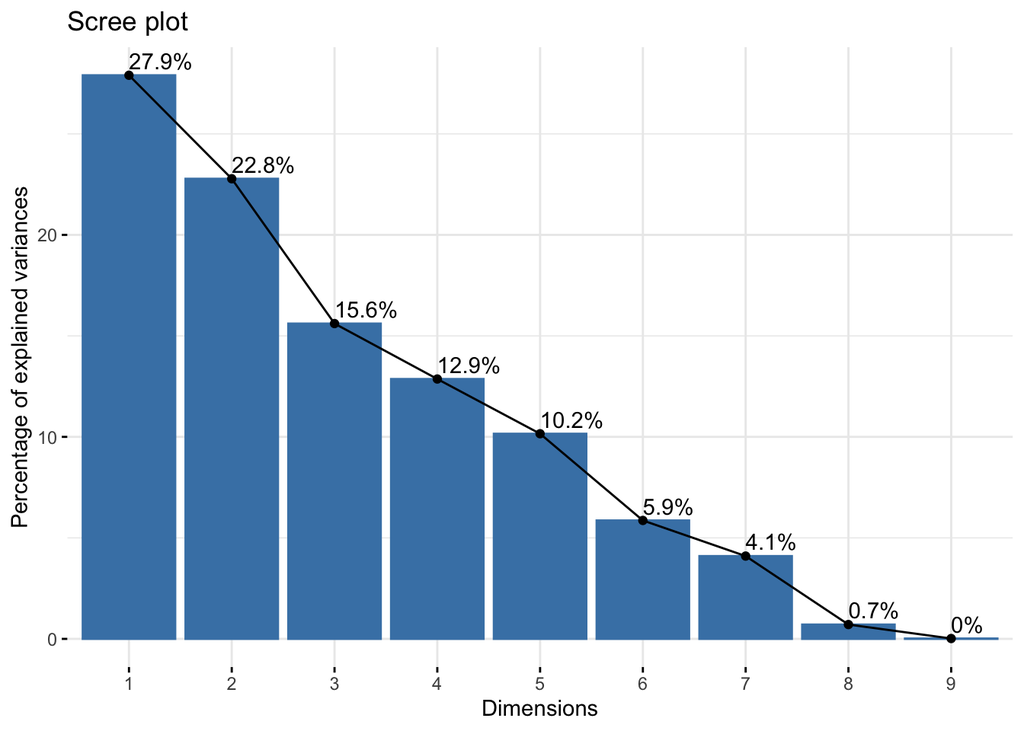

```r
fviz_eig(pca, addlabels = TRUE)
```

The first four dimensions of our pca are really important because they are bigger than 1. The fifth part is almost 1 (it’s 0.91), so we’ll include it too.

Together, these five dimensions make up almost *90%* of variance represented of our dataset.

Lets see now the most contributing variables per dimension.

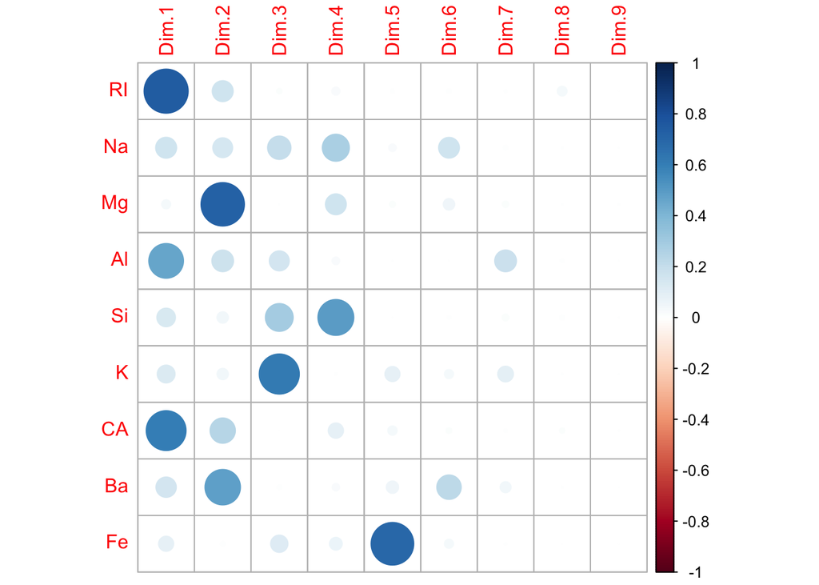

```r
vars = get_pca_var(pca)
corrplot(vars$cos2)
```

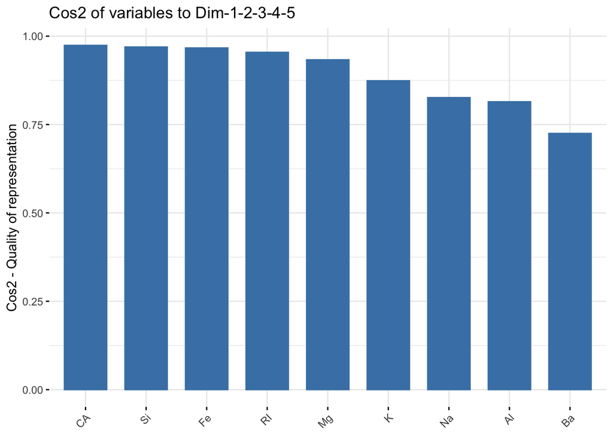

```r
fviz_cos2(pca, choice = "var", axes=1:5)
```

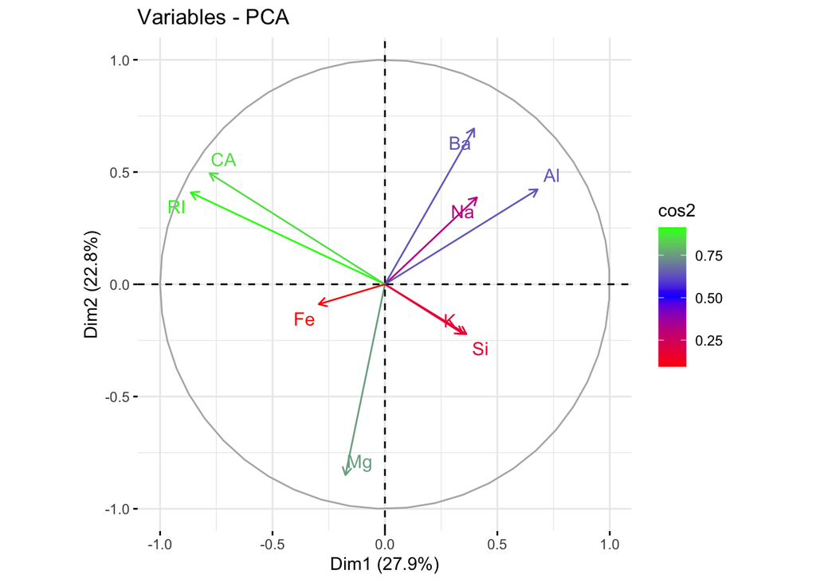

```r
fviz_pca_var(pca, col.var = "cos2", gradient.cols = c("red", "blue", "green"),
             repel = TRUE)
```

So for the first fifth dimensions of the PCA the most contributing variables are:

- CA;
- Si;
- Fe;
- Ri;
- Mg.

# Question 2 - Difference

1. Are there any differences between patients having different chest pain to the angiographic disease status? Report your findings. [Hint: Consider variables ChestPain and AHD][2.5 marks]
2. Is there any difference between cholesterol level and angiographic disease status? Report your findings. [Hint: Consider variables Chol and AHD] [2.5 marks]

Reading the heartdisease dataset for Q1. and Q2: Save the read dataset in a variable called “heartdisease”. Do not change the variable name. For example: `heartdisease <- read.csv("heartdisease.csv")`.

3. Are there any differences between the free sulfur dioxide and quality of the wine? Report your findings. [Hint: Consider variables free sulfur dioxide and quality] [2.5 marks]

Reading the winequality dataset: Save the read dataset in a variable called “wine”. Do not change the variable name. For example: `wine <- read.csv("winequality-red.csv")`.

## Answer

### a

First we need to load the dataset

```r
heartdisease <- read.csv("heartdisease.csv")
head(heartdisease)
```

```
##   Age Sex    ChestPain RestBP Chol Fbs RestECG MaxHR ExAng Oldpeak Slope Ca
## 1  63   1      typical    145  233   1       2   150     0     2.3     3  0
## 2  67   1 asymptomatic    160  286   0       2   108     1     1.5     2  3
## 3  67   1 asymptomatic    120  229   0       2   129     1     2.6     2  2
## 4  37   1   nonanginal    130  250   0       0   187     0     3.5     3  0
## 5  41   0   nontypical    130  204   0       2   172     0     1.4     1  0
## 6  56   1   nontypical    120  236   0       0   178     0     0.8     1  0
##         Thal AHD
## 1      fixed  No
## 2     normal Yes
## 3 reversable Yes
## 4     normal  No
## 5     normal  No
## 6     normal  No
```

Analysing the dataset

```r
summary(heartdisease)
```

```
##       Age             Sex          ChestPain             RestBP
##  Min.   :29.00   Min.   :0.0000   Length:303         Min.   : 94.0
##  1st Qu.:48.00   1st Qu.:0.0000   Class :character   1st Qu.:120.0
##  Median :56.00   Median :1.0000   Mode  :character   Median :130.0
##  Mean   :54.44   Mean   :0.6799                      Mean   :131.7
##  3rd Qu.:61.00   3rd Qu.:1.0000                      3rd Qu.:140.0
##  Max.   :77.00   Max.   :1.0000                      Max.   :200.0
##
##       Chol            Fbs            RestECG           MaxHR
##  Min.   :126.0   Min.   :0.0000   Min.   :0.0000   Min.   : 71.0
##  1st Qu.:211.0   1st Qu.:0.0000   1st Qu.:0.0000   1st Qu.:133.5
##  Median :241.0   Median :0.0000   Median :1.0000   Median :153.0
##  Mean   :246.7   Mean   :0.1485   Mean   :0.9901   Mean   :149.6
##  3rd Qu.:275.0   3rd Qu.:0.0000   3rd Qu.:2.0000   3rd Qu.:166.0
##  Max.   :564.0   Max.   :1.0000   Max.   :2.0000   Max.   :202.0
##
##      ExAng           Oldpeak         Slope             Ca
##  Min.   :0.0000   Min.   :0.00   Min.   :1.000   Min.   :0.0000
##  1st Qu.:0.0000   1st Qu.:0.00   1st Qu.:1.000   1st Qu.:0.0000
##  Median :0.0000   Median :0.80   Median :2.000   Median :0.0000
##  Mean   :0.3267   Mean   :1.04   Mean   :1.601   Mean   :0.6722
##  3rd Qu.:1.0000   3rd Qu.:1.60   3rd Qu.:2.000   3rd Qu.:1.0000
##  Max.   :1.0000   Max.   :6.20   Max.   :3.000   Max.   :3.0000
##                                                  NA's   :4
##      Thal               AHD
##  Length:303         Length:303
##  Class :character   Class :character
##  Mode  :character   Mode  :character
##
##
##
##
```

Check if is there is empty values.

```r
sum(is.na(c(heartdisease$ChestPain, heartdisease$AHD)))
```

```
## [1] 0
```

So we have two categorical with no empty values. The most suitable test in this scenario is a Chi-square test of independence.

For the test we have the following Hypothesis: * Null hypothesis: There is no association between ChestPain and AHD; * Alternative hypothesis: There is association between ChestPain and AHD;

We will assume significance level of 5%.

$$\begin{cases}
H_0: ChestPain \perp AHD \\
H_a: ChestPain \not\perp AHD
\end{cases}$$

$$\alpha = 0.05$$

First we create a contigency table.

```r
ct.chestpain_ahd <- table(heartdisease$ChestPain, heartdisease$AHD)
ct.chestpain_ahd
```

```
##
##                 No Yes
##   asymptomatic  39 105
##   nonanginal    68  18
##   nontypical    41   9
##   typical       16   7
```

We can see that we have 3 degrees of freedom.

```r
chisq.test(ct.chestpain_ahd)
```

```
##
##  Pearson's Chi-squared test
##
## data:  ct.chestpain_ahd
## X-squared = 81.816, df = 3, p-value < 2.2e-16
```

The p-value is less than the significance level of 0.05. So we can reject the null hypotesys ($H_0$) and we conclude that:

There is an *association* between the type of *ChestPain* and *AHD*.

### b

Because *cholesterol* is a continuous variable, it will be useful to know if it distributes normally across the AHD values (*categorical variable*).

```r
shapiro.test.chol_ahd_yes <- shapiro.test(heartdisease$Chol[heartdisease$AHD == "Yes"])
shapiro.test.chol_ahd_no <- shapiro.test(heartdisease$Chol[heartdisease$AHD == "No"])
print(shapiro.test.chol_ahd_yes)
```

```
##
##  Shapiro-Wilk normality test
##
## data:  heartdisease$Chol[heartdisease$AHD == "Yes"]
## W = 0.98977, p-value = 0.4026
```

```r
print(shapiro.test.chol_ahd_no)
```

```
##
##  Shapiro-Wilk normality test
##
## data:  heartdisease$Chol[heartdisease$AHD == "No"]
## W = 0.89734, p-value = 2.878e-09
```

We can conclude that cholesterol (*Chol*) does not follow a normal distribution for the angiographic disease status (*ADH*).

So because of that we will use the Mann-Whitney U test.

For the test we have the following Hypothesis:

- Null hypothesis ($H_0$): There is no difference in Chol between AHD = “Yes” and AHD = “No”;
- Alternative hypothesis ($H_a$): There is a difference in Chol between AHD = “Yes” and AHD = “No”.

We will assume significance level of 5% ($\alpha = 0.05$).

```r
wilcox.test(Chol ~ AHD, data = heartdisease)
```

```
##
##  Wilcoxon rank sum test with continuity correction
##
## data:  Chol by AHD
## W = 9798.5, p-value = 0.03536
## alternative hypothesis: true location shift is not equal to 0
```

Since the p-value is less than 0.05 (significance level), we can reject the null hypothesis. So we can can conclude that there is statistically significant difference between the distribution of Chol levels between patients with and without AHD.

### c

First we need to load the dataset and run the descriptive statistics.

```r
wine <- read.csv("winequality-red.csv")
head(wine)
```

```
##   fixed_acidity volatile_acidity citric_acid residual_sugar chlorides
## 1           7.4             0.70        0.00            1.9     0.076
## 2           7.8             0.88        0.00            2.6     0.098
## 3           7.8             0.76        0.04            2.3     0.092
## 4          11.2             0.28        0.56            1.9     0.075
## 5           7.4             0.70        0.00            1.9     0.076
## 6           7.4             0.66        0.00            1.8     0.075
##   free_sulfur_dioxide total_sulfur_dioxide density   pH sulphates alcohol
## 1                  11                   34  0.9978 3.51      0.56     9.4
## 2                  25                   67  0.9968 3.20      0.68     9.8
## 3                  15                   54  0.9970 3.26      0.65     9.8
## 4                  17                   60  0.9980 3.16      0.58     9.8
## 5                  11                   34  0.9978 3.51      0.56     9.4
## 6                  13                   40  0.9978 3.51      0.56     9.4
##   quality
## 1       5
## 2       5
## 3       5
## 4       6
## 5       5
## 6       5
```

```r
summary(wine)
```

```
##  fixed_acidity   volatile_acidity  citric_acid    residual_sugar
##  Min.   : 4.60   Min.   :0.1200   Min.   :0.000   Min.   : 0.900
##  1st Qu.: 7.10   1st Qu.:0.3900   1st Qu.:0.090   1st Qu.: 1.900
##  Median : 7.90   Median :0.5200   Median :0.260   Median : 2.200
##  Mean   : 8.32   Mean   :0.5278   Mean   :0.271   Mean   : 2.539
##  3rd Qu.: 9.20   3rd Qu.:0.6400   3rd Qu.:0.420   3rd Qu.: 2.600
##  Max.   :15.90   Max.   :1.5800   Max.   :1.000   Max.   :15.500
##    chlorides       free_sulfur_dioxide total_sulfur_dioxide    density
##  Min.   :0.01200   Min.   : 1.00       Min.   :  6.00       Min.   :0.9901
##  1st Qu.:0.07000   1st Qu.: 7.00       1st Qu.: 22.00       1st Qu.:0.9956
##  Median :0.07900   Median :14.00       Median : 38.00       Median :0.9968
##  Mean   :0.08747   Mean   :15.87       Mean   : 46.47       Mean   :0.9967
##  3rd Qu.:0.09000   3rd Qu.:21.00       3rd Qu.: 62.00       3rd Qu.:0.9978
##  Max.   :0.61100   Max.   :72.00       Max.   :289.00       Max.   :1.0037
##        pH          sulphates         alcohol         quality
##  Min.   :2.740   Min.   :0.3300   Min.   : 8.40   Min.   :3.000
##  1st Qu.:3.210   1st Qu.:0.5500   1st Qu.: 9.50   1st Qu.:5.000
##  Median :3.310   Median :0.6200   Median :10.20   Median :6.000
##  Mean   :3.311   Mean   :0.6581   Mean   :10.42   Mean   :5.636
##  3rd Qu.:3.400   3rd Qu.:0.7300   3rd Qu.:11.10   3rd Qu.:6.000
##  Max.   :4.010   Max.   :2.0000   Max.   :14.90   Max.   :8.000
```

```r
unique(wine$quality)
```

```
## [1] 5 6 7 4 8 3
```

`free_sulfur_dioxide` is a continuous variable spread and skewed. `quality` is an ordinal variable.

We also don’t have empty values for these variables.

```r
sum(is.na(c(wine$quality, wine$free_sulfur_dioxide)))
```

```
## [1] 0
```

The next step is to verify if the data is uniform distributed across que quality values.

```r
shaptest_freesulfurdioxide_by_quality <- function(quality) {
  print(quality)
  shapiro.test(wine$free_sulfur_dioxide[wine$quality == quality])
}

lapply(unique(wine$quality), shaptest_freesulfurdioxide_by_quality)
```

```
## [1] 5
## [1] 6
## [1] 7
## [1] 4
## [1] 8
## [1] 3
```

```
## [[1]]
##
##  Shapiro-Wilk normality test
##
## data:  wine$free_sulfur_dioxide[wine$quality == quality]
## W = 0.90773, p-value < 2.2e-16
##
##
## [[2]]
##
##  Shapiro-Wilk normality test
##
## data:  wine$free_sulfur_dioxide[wine$quality == quality]
## W = 0.91191, p-value < 2.2e-16
##
##
## [[3]]
##
##  Shapiro-Wilk normality test
##
## data:  wine$free_sulfur_dioxide[wine$quality == quality]
## W = 0.85051, p-value = 4.962e-13
##
##
## [[4]]
##
##  Shapiro-Wilk normality test
##
## data:  wine$free_sulfur_dioxide[wine$quality == quality]
## W = 0.85004, p-value = 9.405e-06
##
##
## [[5]]
##
##  Shapiro-Wilk normality test
##
## data:  wine$free_sulfur_dioxide[wine$quality == quality]
## W = 0.79792, p-value = 0.00142
##
##
## [[6]]
##
##  Shapiro-Wilk normality test
##
## data:  wine$free_sulfur_dioxide[wine$quality == quality]
## W = 0.76929, p-value = 0.006131
```

By the results we can see that *free sulfur dioxide* does not follow a normal distribution across the *quality* of the wine.

So because the *quality* is a ordinal variable we will use the Spearman’s Rank Correlation test.

So we have the follow Hypothesis:

- Null Hypothesis ($H_0$): There is no monotonic association between free sulfur dioxide levels and wine quality;
- Alternative Hypotesis ($H_a$): There is monotonic association between free sulfur dioxide levels and wine quality.

$$\begin{cases}
H_0: \rho_s = 0 \\
H_a: \rho_s \neq 0
\end{cases}$$

As usual we will assume significance level of 5% ($\alpha = 0.05$).

```r
cor.test(wine$free_sulfur_dioxide, wine$quality, method = "spearman", exact=FALSE)
```

```
##
##  Spearman's rank correlation rho
##
## data:  wine$free_sulfur_dioxide and wine$quality
## S = 720158572, p-value = 0.02288
## alternative hypothesis: true rho is not equal to 0
## sample estimates:
##         rho
## -0.05690065
```

So based on the result we *reject the null hypothesis* for a confidence level of 0.05. The data indicate a slight inverse relationship (negative and near 0), suggesting that *wine quality slightly improves* as *free sulfur dioxide levels decrease*.

# Question 3 - Predictive Statistics

1. Model the relationship between humidity and total rented bikes. How good is the model? [Hint: Consider the variables hum and cnt][1.5 marks]
2. Include a dummy variable (working day) to the model and compare the relationship. Report your findings. [1.5 marks]

Reading the bikesharing dataset: Save the read dataset in a variable called “bike”. Do not change the variable name. For example: `bike <- read.csv("bikesharing.csv")`

## Answer

### a

First we need to load the dataset and look at data.

```r
bike <- read.csv("bikesharing.csv")
head(bike)
```

```
##   instant     dteday season yr mnth holiday weekday workingday weathersit
## 1       1 2011-01-01      1  0    1       0       6          0          2
## 2       2 2011-01-02      1  0    1       0       0          0          2
## 3       3 2011-01-03      1  0    1       0       1          1          1
## 4       4 2011-01-04      1  0    1       0       2          1          1
## 5       5 2011-01-05      1  0    1       0       3          1          1
## 6       6 2011-01-06      1  0    1       0       4          1          1
##       temp    atemp      hum windspeed casual registered  cnt
## 1 0.344167 0.363625 0.805833 0.1604460    331        654  985
## 2 0.363478 0.353739 0.696087 0.2485390    131        670  801
## 3 0.196364 0.189405 0.437273 0.2483090    120       1229 1349
## 4 0.200000 0.212122 0.590435 0.1602960    108       1454 1562
## 5 0.226957 0.229270 0.436957 0.1869000     82       1518 1600
## 6 0.204348 0.233209 0.518261 0.0895652     88       1518 1606
```

```r
summary(bike)
```

```
##     instant         dteday              season            yr
##  Min.   :  1.0   Length:731         Min.   :1.000   Min.   :0.0000
##  1st Qu.:183.5   Class :character   1st Qu.:2.000   1st Qu.:0.0000
##  Median :366.0   Mode  :character   Median :3.000   Median :1.0000
##  Mean   :366.0                      Mean   :2.497   Mean   :0.5007
##  3rd Qu.:548.5                      3rd Qu.:3.000   3rd Qu.:1.0000
##  Max.   :731.0                      Max.   :4.000   Max.   :1.0000
##       mnth          holiday           weekday        workingday
##  Min.   : 1.00   Min.   :0.00000   Min.   :0.000   Min.   :0.000
##  1st Qu.: 4.00   1st Qu.:0.00000   1st Qu.:1.000   1st Qu.:0.000
##  Median : 7.00   Median :0.00000   Median :3.000   Median :1.000
##  Mean   : 6.52   Mean   :0.02873   Mean   :2.997   Mean   :0.684
##  3rd Qu.:10.00   3rd Qu.:0.00000   3rd Qu.:5.000   3rd Qu.:1.000
##  Max.   :12.00   Max.   :1.00000   Max.   :6.000   Max.   :1.000
##    weathersit         temp             atemp              hum
##  Min.   :1.000   Min.   :0.05913   Min.   :0.07907   Min.   :0.0000
##  1st Qu.:1.000   1st Qu.:0.33708   1st Qu.:0.33784   1st Qu.:0.5200
##  Median :1.000   Median :0.49833   Median :0.48673   Median :0.6267
##  Mean   :1.395   Mean   :0.49538   Mean   :0.47435   Mean   :0.6279
##  3rd Qu.:2.000   3rd Qu.:0.65542   3rd Qu.:0.60860   3rd Qu.:0.7302
##  Max.   :3.000   Max.   :0.86167   Max.   :0.84090   Max.   :0.9725
##    windspeed           casual         registered        cnt
##  Min.   :0.02239   Min.   :   2.0   Min.   :  20   Min.   :  22
##  1st Qu.:0.13495   1st Qu.: 315.5   1st Qu.:2497   1st Qu.:3152
##  Median :0.18097   Median : 713.0   Median :3662   Median :4548
##  Mean   :0.19049   Mean   : 848.2   Mean   :3656   Mean   :4504
##  3rd Qu.:0.23321   3rd Qu.:1096.0   3rd Qu.:4776   3rd Qu.:5956
##  Max.   :0.50746   Max.   :3410.0   Max.   :6946   Max.   :8714
```

```r
sum(is.na(c(bike$hum, bike$cnt)))
```

```
## [1] 0
```

So we don’t have empty values for *hum* and *cnt*.

*cnt* (Represent the number of rented bikes) has a range between 22 and 8714. Its shows a spread data but the mean and median are close to each other suggesting that the distribution is symmetric.

Using the linear regression we have the following hypothesis:

- Null ($H_0$) : There is no linear relationship between hum and cnt;
- Alternative ($H_a$): There is linear relationship between hum and cnt.

$$\begin{cases}
H_0: \beta_{hum} = 0 \\
H_a: \beta_{hum} \neq 0
\end{cases}$$
Our model is a linear equation:
$$cnt = \beta_0 + \beta_{hum}hum + \epsilon$$
Where:

- cnt (number of bikes rented) is the *dependent variable*;
- $\beta_0$ is *intercept* of the regression line;
- $\beta_{hum}$ is the *slope* of the regression. It quantifies the change in cnt for one unit in hum;
- hum (hum) is the *independent variable*;
- $\epsilon$ the *residual*. The difference between the observed values and values predicted by the model.

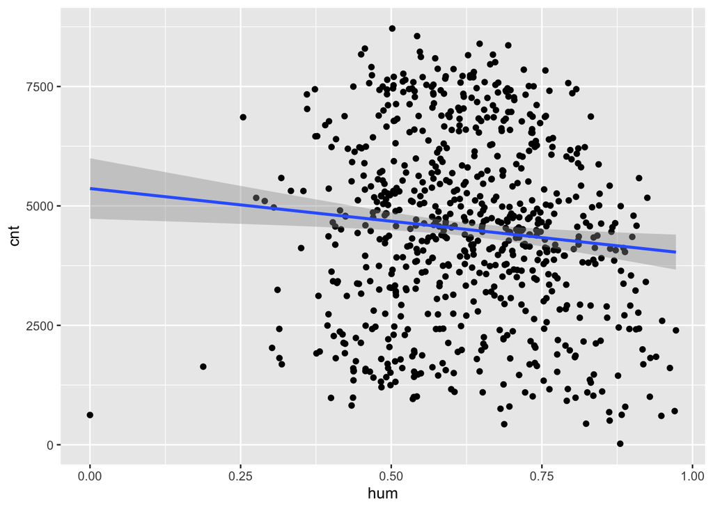

```r
ggplot(bike, aes(x = hum, y = cnt)) + geom_point() + geom_smooth(method = lm, formula = y ~ x)
```

Doing the scatterplot we don’t find a great evidence that humidity will influence the number of bike rentals. Lets run the linear regression model.

```r
model <- lm(cnt ~ hum, data = bike)
summary(model)
```

```
##
## Call:
## lm(formula = cnt ~ hum, data = bike)
##
## Residuals:
##     Min      1Q  Median      3Q     Max
## -4741.0 -1386.9    50.3  1439.3  4036.8
##
## Coefficients:
##             Estimate Std. Error t value Pr(>|t|)
## (Intercept)   5364.0      322.7  16.623  < 2e-16 ***
## hum          -1369.1      501.2  -2.732  0.00645 **
## ---
## Signif. codes:  0 '***' 0.001 '**' 0.01 '*' 0.05 '.' 0.1 ' ' 1
##
## Residual standard error: 1929 on 729 degrees of freedom
## Multiple R-squared:  0.01013,    Adjusted R-squared:  0.008774
## F-statistic: 7.462 on 1 and 729 DF,  p-value: 0.006454
```

Looking at the results we to the R-squared values, they are quite low suggesting that approximately 0.8% (Adjusted R-squared: 0.008774) of the variance contribute for the number of bike rentals.

Because the F-Statistics is a bigger number than 2.5 (with p value of 0.006454) (https://www.sciencedirect.com/topics/mathematics/f-test) we can reject the null hypothesis (for a significance level of 0.01).

Our linear model equation is the following one:
$$cnt=5364.0 − 1369.1 \times hum + \epsilon$$

We conclude that: *There is a negative relationship between humidity (hum) and the number of the rented bikes (cnt) but is very low (R-Squared)*.

### b

Adding the working day variable we will end up in *multiple linear regression model* with the following expanded equation:
$$cnt = \beta_0 + \beta_{hum}hum + \beta_{workingday}workingday + \epsilon$$

For the test we have one null and one alternative hypothesis per variable.
$$\begin{cases}
H_0: \beta_{hum} = 0 \\
H_a: \beta_{hum} \neq 0
\end{cases}\\
\begin{cases}
H_0: \beta_{workingday} = 0 \\
H_a: \beta_{workingday} \neq 0
\end{cases}\\$$
Lets run the linear regression model.

```r
mmodel <- lm(cnt ~ hum + workingday, data = bike)
summary(mmodel)
```

```
##
## Call:
## lm(formula = cnt ~ hum + workingday, data = bike)
##
## Residuals:
##     Min      1Q  Median      3Q     Max
## -4838.0 -1394.6    25.8  1407.1  4215.4
##
## Coefficients:
##             Estimate Std. Error t value Pr(>|t|)
## (Intercept)   5195.9      336.6  15.438  < 2e-16 ***
## hum          -1390.1      500.7  -2.777  0.00563 **
## workingday     265.0      153.3   1.729  0.08424 .
## ---
## Signif. codes:  0 '***' 0.001 '**' 0.01 '*' 0.05 '.' 0.1 ' ' 1
##
## Residual standard error: 1926 on 728 degrees of freedom
## Multiple R-squared:  0.01418,    Adjusted R-squared:  0.01147
## F-statistic: 5.236 on 2 and 728 DF,  p-value: 0.005525
```

$$cnt = 5195.9 - 1390.1 \times hum + 265.0 \times workingday + \epsilon$$

The model estimates an increase of 265 bikes rented on working days compared to non-working days. However, due to the p-value being higher than the 0.05 significance level, this variable is not considered statistically significant and does not provide strong evidence of affecting bike rentals.

When analyzing the R-squared values, we observe that the model explains a minimal portion of the variability in the number of bikes rented, indicating its limited explanatory power.